# Homburg-CustomerUncertaintyDownsizing-2012-JM.pdf

Converted from PDF `Homburg-CustomerUncertaintyDownsizing-2012-JM.pdf` · 19 pages · anchors: page `#pN`, block `#pN-bK`

Page 1

**112 *Journal of Marketing* Volume 76 (May 2012), 112–129 © 2012, American Marketing Association ISSN: 0022-2429 (print), 1547-7185 (electronic)**

### Christian Homburg, Martin Klarmann, & Sabine Staritz

## **Customer Uncertainty Following Downsizing: The Effects of Extent of**

## **Downsizing and Open**

## **Communication**

Although downsizing has become a nearly universal managerial practice, many downsizing initiatives fail. To explain this phenomenon, previous research has mainly investigated possible negative consequences for employees remaining in the firm while largely neglecting customer reactions to downsizing and the issues surrounding its implementation. The authors describe three studies analyzing how downsizing at a firm’s point of customer contact affects customers and how managers can influence customer reactions through open communication. The first study, a manager study, is based on an executive survey of a sample of more than 100 downsizing projects. The other two studies are customer studies that use an experimental scenario method. Across the two methods, results show that the extent of downsizing is linked to customer uncertainty. In addition, both survey results and experimental results reveal that open downsizing communication carries substantial risks for downsizing firms. Although open communication reduces customer uncertainty if customers have strong informal ties with the firm’s employees or perceive a firm’s products as important, it may increase customer uncertainty in other situations.

*Keywords*: customer uncertainty, downsizing, open communication, contact employees

Christian Homburg is Professor of Business Administration and Marketing, Chair of the Marketing Department, University of Mannheim, Germany, and Professorial Fellow, Department of Management and Marketing, University of Melbourne (e-mail: homburg@bwl.uni-mannheim.de). Martin Klarmann is Professor of Marketing, Karlsruhe Institute of Technology (e-mail: martin.klarmann@kit.edu). Sabine Staritz is Head of Marketing, Sales, and Corporate Relations, Mannheim Business School (e-mail: staritz@ mannheim-business-school.com). The authors thank Anne Meister for her support in conducting the second study and Steffen Würtz for his support in conducting the third study. Ajay Kohli served as area editor for this article.

## **D**

uring the past two decades, firms have increasingly relied on downsizing to cut costs and to improve productivity and competitiveness (Freeman and Cameron 1993). These major workforce reductions have become particularly prevalent during the ongoing economic crisis. In the fourth quarter of 2008 alone, the U.S. Bureau of Labor Statistics counted 3582 mass layoff events that resulted in job loss for 641,714 employees. In the second quarter of 2010, there were 2011 mass layoffs affecting 382,007 employees (Bureau of Labor Statistics 2010).

However, the literature offers no clear consensus as to whether downsizing increases organizational efficiency (Datta et al. 2010). In attempting to understand downsizing failures, researchers have primarily examined the workplace. In many organizations undergoing radical change (DiFonzo and Bordia 1998; Rafferty and Griffin 2006), employee uncertainty and rumors appear to dominate post-

downsizing work environments, fueling job insecurity (Brockner et al. 1992), role conflict (Lewin 2001), and distrust in the organization (Brockner et al. 2004).

While research has studied downsizing from the perspective of shareholders and employees, customer reactions constitute a gap in the literature (Datta et al. 2010). Moreover, “it appears as if the important relationship between customer satisfaction and stability in key contact personnel is overlooked by organizations engaging in downsizing” (Lewin 2009, p. 284). Bastien and Hostager (2003) warn that customers may well experience uncertainty following downsizing, particularly when layoffs involve contact employees (Bendapudi and Leone 2002).

For at least two reasons, findings pertaining to employee reactions to downsizing do not map to such a customer context. While layoffs are often life-altering events for the affected employees (Bennett et al. 1995), the risks that downsizing present to customers usually have only a business dimension. In addition, a strong difference exists in terms of information availability. While employee awareness of the downsizing will always be high, customer awareness may not. Therefore, research on employee reactions indicates that open communication reduces uncertainty (Chadwick, Hunter, and Walston 2004). However, downsizing communication targeted at customers may draw additional attention to a firm’s actions that customers might not have noticed otherwise. Thus, it may sometimes even increase uncertainty rather than reduce it.

Page 2

**Customer Uncertainty Following Downsizing / 113**

Our study begins at this point. We examine how downsizing at a firm’s point of contact with the customer—that is, in sales and sales-related services—affects customer uncertainty and how managers can influence customer reactions with open communication. We expect that open communication reduces uncertainty only if customers have strong informal ties with the firm’s employees or perceive a firm’s products to be important. In addition, we analyze customer satisfaction and firm performance as outcomes of customer uncertainty.

It is important to briefly review previous marketing research on downsizing. Whereas some studies analyze how downsizing affects buying behavior if the buying firm downsizes (Lewin 2001, 2003), others have examined the effects of supplier downsizing on customers. They focus on the effect of downsizing on customer satisfaction, typically reporting a negative relationship (Lewin 2009; Lewin, Beimans, and Ulaga 2010; Lewin and Johnston 2008; McElroy, Morrow, and Rude 2001).

Against this background, the current study makes at least three contributions. First, we introduce the concept of customer uncertainty following downsizing. Second, while previous research has mostly treated downsizing as a yes/no variable, we propose and test hypotheses that link customer reactions to the number of contact employees laid off and the number of customers facing a contact employee change. Third, to the best of our knowledge, no previous research has studied how managers can influence customer reactions to downsizing. Our study contributes by addressing how managers can use communication to reduce customer uncertainty.

We test most of our hypotheses twice, using two independent methods and three empirical studies. Our first study is a manager study using data from a cross-firm,

cross-industry survey of executives who had recently implemented downsizing projects at their organization’s interface with customers. Despite the great difficulty of identifying relevant firms and the confidentiality typically surrounding downsizing, we were able to obtain key informant data on 109 downsizing projects (in as many firms). In addition, we conducted two studies using an experimental scenario approach to analyze downsizing from a customer perspective. These studies examine how the extent of downsizing (Customer Study 1) and open communication (Customer Study 2) are linked to customer uncertainty in individual firm–customer relationships.

**Conceptual Framework** Figure 1 presents the framework of our study. In an examination of the consequences of downsizing at a firm’s point of contact with the customer, a fundamental issue is whether contact employee turnover directly affects the customer (Bendapudi and Leone 2002). Therefore, we distinguish two facets of the extent of downsizing: the number of contact employee layoffs and the customer contact changes*.*

The number of contact employee layoffs refers to the total number of customer contact employees laid off. Thus, this facet reflects the extent of the downsizing from the firm’s perspective. However, it does not necessarily capture the degree to which customers actually lose their key contact employee, because it also comprises layoffs of back office staff and call center personnel.

Therefore, we consider customer contact changes, defined as the extent to which a firm’s customers lose their previous customer contact employee, as a second facet of the extent of downsizing. This aspect reflects the extent of downsizing from a customer perspective. It focuses on the customer’s experience of losing a familiar contact

**FIGURE 1 Conceptual Framework**

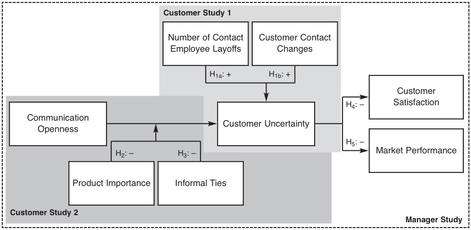

NOTE: figure/graphic rendered as an image from the PDF; its content is not machine-readable text. Caption (if any) follows as the next block.

**text found inside the figure**

**Customer Study 2**

**Manager Study**

H2: – H3: –

**Customer Study 1**

H1a: + H1b: +

H4: –

H5: –

Number of Contact

Employee Layoffs

Customer Contact

Changes

Product Importance Informal Ties

Market Performance

Customer Satisfaction

Customer Uncertainty Communication

Openness

Page 3

employee, regardless of whether the firm replaces this employee or directs the customer to an online portal or call center.

Because uncertainty constitutes an important outcome of organizational change at the employee level (Rafferty and Griffin 2006), we apply this construct to customers. “Customer uncertainty” refers to the customer’s state of doubt about what the downsizing signifies regarding both the continuance and the future quality of the relationship with the downsizing supplier (DiFonzo, Bordia, and Rosnow 1994). “Customer satisfaction” refers to the customer’s cumulative evaluation of the purchase and consumption of a supplier’s offering. “Firm performance” is the market performance and profitability of a firm or business unit relative to its competitors.

On the basis of research on employee reactions to downsizing (Schweiger and Denisi 1991) and the crisis communication literature (Coombs 1999), we also include communication openness in the model. A literature review in search of defining characteristics of open communication reveals three interrelated themes. First, firms must provide information on their own initiative. Otherwise, they will be suspected of hiding something (Arpan and Pompper 2003). Second, a timely response to new developments is essential, as “subsequent stories never catch up with the original” (Pines 1985, p. 17). Third, to reduce the risk of false rumors, information should be complete (Coombs 1999) because “what you don’t say can hurt you” (Kaufmann, Kesner, and Hazen 1994, p. 30). Therefore, communication openness is the extent to which a firm discloses information about the downsizing proactively, promptly, and completely. We consider these dimensions reflective indicators of the construct. Thus, we do not examine the relative importance of the individual dimensions but rather analyze open communication as a whole. We also consider two moderators that may affect communication effectiveness. “Product importance” is the customer’s perception of the overall significance of a product, and “informal ties” refer to the extent to which customers and contact employees connect on an informal level.

### **Hypotheses Development**

#### *The Effect of the Extent of Downsizing*

We expect that both facets of the extent of downsizing bear on customer uncertainty. In most cases, downsizing is a reaction to performance problems (Baumol, Blinder, and Wolff 2003). Thus, customers are likely to associate downsizing with organizational decline, and they may begin to doubt the long-term reliability of a supplier. Here, the number of layoffs is likely to act as a proxy for the degree of a firm’s difficulties. Moreover, downsizing is often believed to reflect a firm’s character (Love and Kraatz 2009). Because mass media outlets often portray downsizing as an opportunistic behavior and a violation of responsibilities, customers may apply this interpretation to their own relationship with the supplier. In addition, downsizing triggers uncertainty among employees that is likely to be contagious and transmitted to customers. Because negative employee

reactions are directly linked to the magnitude of the downsizing (Trevor and Nyberg 2008), this also suggests that customer uncertainty is linked to the number of layoffs.

It is worth emphasizing that the signaling effect of downsizing and emotional contagion may lead to uncertainty even if the downsizing does not directly affect customers. At the same time, the degree to which they are affected, reflected in the extent of customer contact changes, can also lead to uncertainty. First, the change leads to the experience of divided loyalties because customers typically feel loyal to both the selling firm and their contact employee (Palmatier, Scheer, and Steenkamp 2007). If a firm forces the contact employee to leave, customers may wonder whether they should end the relationship with the firm out of loyalty to the employee.

Second, research on the status quo bias provides ample evidence that people prefer the status quo over change (Samuelson and Zeckhauser 1988). Change leads to uncertainty because its final outcome cannot be perfectly anticipated. This logic most likely extends to contact employee change. Customers often perceive the contact employee as an important part of a firm’s offerings: “Many customers believe that their satisfaction with a particular vendor hinges on a single key contact employee” (Bendapudi and Leone 2001, p. 106). Thus:

H1: The extent of downsizing as indicated by (a) the number

of contact employee layoffs and (b) customer contact changes is positively related to customer uncertainty.

#### *Effects of Downsizing Communication*

*Theoretical background*. As intuition suggests, numerous theories, such as uncertainty reduction theory (Berger and Calabrese 1975) and information economics (Hirshleifer and Riley 2002), hold that information reduces uncertainty. Thus, they imply that downsizing communication invariably reduces customer uncertainty. However, theories on the pragmatics of human communication (Levinson 1983) suggest that this relationship is much more complex and that communication is a possible source of uncertainty because messages convey more than their explicit content. To infer implicit content, listeners rely on two additional sources. First, cues from the situational context aid message interpretation (Levinson 1983). Thus, misunderstandings and uncertainty can arise in ambiguous contexts that allow for numerous interpretations of a message. Second, general principles inherent to human communication guide interpretation. One of these principles is the “maxim of relation” (Grice 1989), which states that communicators interpret all messages they receive under the assumption that they are relevant to them. If their relevance is not intuitively clear, recipients will look for interpretations to establish relevance. In these cases, information creates uncertainty. In summary, these considerations suggest that communication varies in effectiveness with the situational context and may in some situations even lead to an increase of uncertainty. The next two hypotheses reflect this theoretical argument.

*The moderating effect of product importance on the communication*–*uncertainty link*. In what follows, we argue that the importance of a firm’s offering to its customers

**114 / Journal of Marketing, May 2012**

Page 4

**Customer Uncertainty Following Downsizing / 115**

influences the direction of the link between open communication and customer uncertainty. In particular, if customers perceive a product as critical, they probably will have spent much time choosing the right supplier and adapting their own processes accordingly. Thus, switching the supplier can be expected to be more costly. According to transaction cost economics, customers will seek to cooperate closely with their supplier (Rindfleisch and Heide 1997). Thus, customers who assign great importance to the products will perceive downsizing information as highly relevant. Open communication will reassure them that they are receiving timely information on important matters. Thus, it can be expected to reduce uncertainty.

In the case of customers for whom product importance is low, open downsizing communication instead presents a double risk. First, it will increase awareness of an issue that many customers would not have noticed otherwise. Second, under the maxim of relation, these customers are likely to respond with additional interpretation and information search processes. If product importance is low, open communication may well increase uncertainty. Thus:

H2: If product importance is high, open communication

reduces customer uncertainty, whereas it increases customer uncertainty if product importance is low.

*The moderating effect of informal ties on the communication–uncertainty link*. We also expect that the strength of informal ties between customers and employees influences the effectiveness of open communication. Research on personal relationships between employees and customers shows that customers may develop a strong emotional bond to their contact employee (Palmatier, Scheer, and Steenkamp 2007). In this case, the customer will perceive information about the downsizing as relevant, and open communication will reduce uncertainty. Moreover, if strong informal ties exist between customers and employees, chances are good that customers will learn about the downsizing anyway. This raises the importance of communicating openly to avoid creating the impression of hiding important information (Arpan and Pompper 2003). At the same time, when employee– customer relationships are mostly professional, employees are likely to stick to established communication guidelines. Therefore, the risk of creating unnecessary awareness of the downsizing through open communication increases. Thus:

H3: If informal ties are strong, communication openness

reduces customer uncertainty, whereas if informal ties are weak, it increases customer uncertainty.

#### *Outcomes of Customer Uncertainty*

*The effect on customer satisfaction*. Because previous research has indicated that customer satisfaction results from a comparison between expected and perceived performance (Oliver 1997), it is important to consider how customer uncertainty may be related to these two components. Research regularly distinguishes three types of expectations. First, customers have expectations regarding an ideal product or service in a category (Woodruff, Cadotte, and Jenkins 1983). These expectations offer the dominating comparison standard for satisfaction judgments, and they

tend to be stable over time (Boulding et al. 1993). This makes them unlikely to be affected by a customer’s experience of the downsizing of a single supplier. Second, customers may rely on normative, or “should,” expectations. They represent what customers view “as reasonable and feasible” on the basis of what they know about industry standards (Boulding et al. 1993, p. 9). Again, experiencing downsizing with a single firm is not likely to affect this type of expectation. Third, customers form “will” expectations (Zeithaml, Berry, and Parasuraman 1993), which are predictions of the performance a product or service provider will actually deliver. Customer uncertainty can be thought of as the degree of difficulty in making these predictions, though it is conceptually unrelated to their content.

Consequently, we argue that customer uncertainty affects only the perceived performance of a firm’s offerings. In this context, customers often regard uncertainty about a product and its consumption negatively and as something to be avoided (Reimann, Lünemann, and Chase 2008). As a result, uncertainty is likely to have a negative influence on customer performance perceptions and thus on satisfaction. Moreover, if customers are uncertain about the future potential of a relationship, they may evaluate the current performance of the firm more critically.

Finally, to enter and maintain business relationships, customers must often make specific investments, particularly in business-to-business (B2B) environments (Ganesan 1994), which raise switching costs. According to transaction cost economics, these investments increase a customer’s interest in long-term relationships with a supplier (Rindfleisch and Heide 1997). Therefore, uncertainty about the future of the relationship will be perceived as particularly negative. Thus, we hypothesize the following:

H4: Customer uncertainty is negatively related to customer

satisfaction.

*The effect on firm performance*. A key element of customer uncertainty is that customers doubt the long-term viability of their business relationship with the supplier firm. Thus, in the short run, they are likely to adopt a short-term orientation in their dealings with the supplier (Ganesan 1994). Moreover, they can be expected to strive for more independence from the supplier. Possible reactions include a change in ordering behavior (smaller quantities at a higher frequency), reduced interest in cross-buying, and a hesitation to recommend the supplier. At a time when many firms are focusing on establishing relationships with their customers (Palmatier et al. 2006), these uncertainty-induced behaviors are likely to hurt firm performance. Thus:

H5: Customer uncertainty is negatively related to firm

performance.

*The mediating effect of customer uncertainty*. Downsizing projects vary greatly, with some firms reducing their personnel simply to cut costs and others combining downsizing with large restructuring activities (Freeman and Cameron 1993). Likewise, service quality will also vary after the downsizing. Firms with a high level of organizational slack before the downsizing will be able to preserve their service quality much more easily (Love and Nohria

Page 5

2005) because they can compensate for negative effects of workforce reductions by improving their processes. In contrast, firms in which customer-related processes were efficient before the downsizing may experience difficulty in maintaining quality standards after the downsizing.

In light of these considerations, we do not expect a direct negative effect of downsizing on customer satisfaction. This expectation is consistent with the general finding that changes in productivity are not clearly linked to changes in customer satisfaction (Anderson, Fornell, and Rust 1997). However, as outlined previously, we expect an indirect effect, through uncertainty, of the extent of downsizing on customer satisfaction. Therefore, we hypothesize the following:

H6: The effect on customer satisfaction of (a) the number of

contact employee layoffs and (b) contact employee changes is fully mediated by customer uncertainty.

### **Manager Study**

#### *Methodology*

*Objective, data collection, and sample*. In this manager study, we examine our conceptual framework as a whole. The unit of analysis is a downsizing firm (or strategic business unit [SBU]). Because most of the information necessary is not available in secondary data sources, we rely on a large cross-industry, cross-firm survey using key informants to collect data for hypothesis testing. To the best of our knowledge, this sample is one of the first of this type to be used in downsizing research. A notable exception is Lewin (2001, 2003), who studies the effects of downsizing in customer firms (whereas we investigate the effects of downsizing in supplier firms).

We defined the population of our study as all firms that had significantly reduced their workforce in sales and salesrelated services within the previous five years. Because data on this type of workforce reduction are not readily available, we employed a multistep sampling approach. First, using database searches, we identified 2500 firms that had reduced their overall workforce by at least 5% within the past five years, as the 5% threshold commonly defines downsizing (Guthrie and Datta 2008). Then, we identified executives with sales responsibility in these firms, resulting in 2433 contacts to whom we subsequently sent a questionnaire. In line with the established definition of downsizing as a major workforce reduction (Freeman and Cameron 1993), we asked respondents to return the questionnaire only if their firm had “substantially reduced the workforce in sales or sales-related services within the last five years.” We further specified the following: “As a guideline, a workforce reduction is generally considered to be substantial if the number of employees is cut down by five percent or more.” Thus, we ultimately relied on practitioner perceptions of whether a project was considered downsizing.

To determine the number of firms in our original sample that had actually downsized at the interface to the customer, we directly contacted 460 members of the sample by telephone. Providing the 5% threshold as a guideline, we asked them whether the firm had engaged in a substantial workforce reduction at the customer interface. We found that

only approximately 36% of the firms in the total sample had engaged in downsizing at the customer contact point in the relevant time span. Therefore, the size of our relevant sample was approximately 875 firms.

Two weeks after sending out the questionnaire, we contacted each firm from the overall sample by telephone. In addition, six weeks after the initial mailing, we mailed the survey a second time to all sample members who had not yet responded. In the end, we received 109 useable questionnaires (for a 12.46% response rate). As respondents mentioned frequently, downsizing is a highly sensitive topic, and firms do not readily share information. Therefore, we believe this response rate (and sample size) to be satisfactory. Table 1 shows the sample composition.

**116 / Journal of Marketing, May 2012**

**TABLE 1 Sample Composition: Manager Study**

|  | % |
| --- | --- |
| Industries Electronics Machinebuilding Transport/logistics Banks/insurance Chemicals Food Metalprocessing Building Automotive Other | 11 10 8 8 6 6 6 6 6 33 |
| AnnualRevenuesoftheFirm/SBU <$50million $50 million–$100 million $100 million–$250 million $250 million–$500 million $500 million–$1 billion >$1billion | 13 18 30 13 11 14 |
| PositionofRespondents Vicepresidentmarketing/headofmarketing Vicepresidentsales/headofsales Vicepresidentmarketingandsales/ | 5 55 5 |
| headofmarketingandsales Generalmanagementresponsibility | 20 |
| (headofSBU managingdirector , , chiefexecutiveofficer) Other | 15 |
| NumberofEmployeesoftheFirm/SBU <50 50 100 – 100 250 – 250 500 – 500 1000 – 1000 4000 – >4000 | 15 7 19 12 15 21 11 |
| PercentageofSalesForceLaidOff 0% –<5% 5% –<10% 10% –<15% 15% –<25% 25% –<50% 50% –<75% 75% –<100% | 10 14 18 18 33 4 3 |

NOTE: table converted from PDF layout to HTML text; cell boundaries are reconstructed. See PDF if exact alignment matters.

Notes: The information in this table is based on a sample of n = 109

firms.

Page 6

**Customer Uncertainty Following Downsizing / 117**

*Measures and measurement evaluation*. We followed standard scale development procedures. We then refined our measures according to input from colleagues and a pretest among a dozen potential participants. A key insight from the pretest was that managers typically do not have data on the exact number of customers affected by downsizing. Therefore, to measure customer contact change, we resorted to seven-point scales with anchors “no one” and “all.” Appendix A provides detailed information on all measures. Because all constructs are assessed by managers, in this study we refer to “perceived customer uncertainty” and “perceived customer satisfaction.”

We incorporate control variables into all models. First, because the medium may play a key role in determining communication outcomes, in all models including communication openness, we control for the media focus of the communication. Second, customer perceptions may also be linked to whether downsizing is an “institutionalized practice” (Datta et al. 2010, p. 286). Therefore, we control for the institutionalization of downsizing (i.e., the degree to which a firm’s competitors also engage in downsizing). Third, to account for different customer interaction models, we include the revenue share of services, the revenue share of direct sales, and the revenue share of B2B transactions. Finally, because customers could expect larger firms to have more resource slack to absorb cuts without lessening service quality, we control for firm size.

To assess measure reliability and validity, we estimated a confirmatory factor analysis model with all constructs. When applicable, composite reliabilities (CRs) and Cronbach’s alphas exceeded the .70 threshold. In addition, squared correlations are not larger than their average variances extracted (AVEs) for any pairs of constructs, indicating discriminant validity (Fornell and Larcker 1981). Table 2 shows descriptive statistics, Cronbach’s alphas, AVEs, CRs, and observed correlations. In addition, whenever possible, we computed item reliabilities (see Appendix A). They indicate the proportion of indicator variance explained through the underlying construct.

*Further measure validation through additional data*. Because we use managerial perceptions to measure customer uncertainty and customer satisfaction, we collected customer data to establish construct validity. In particular, we asked survey respondents to provide contact information for at least five representative customers. However, “resizing companies are reluctant to allow researchers access to their customers” (Bastien and Hostager 2003, p. 158), and more than 40% of our respondents explicitly cited the sensitivity of downsizing-related issues as the reason for not participating. In total, 29 business units provided contact information, allowing us to obtain data from 95 customers. We computed SBU means of customer uncertainty and customer satisfaction on the basis of these responses. Correlations of .68 for customer uncertainty (*p* < .05) and .63 for customer satisfaction (*p* < .05) support the accuracy of the key informant responses.

We also used the customer data to test H1–H3. Because in this data set, customers are nested in firms, we analyzed a multilevel model. It replicates the model described in the

next section while measuring customer uncertainty through customers. All coefficients have signs consistent with the hypotheses. Moreover, despite the small n at the firm level, most effects are also statistically significant. These results further support our hypotheses.

Finally, to validate the firm performance measure in our model, we collected publicly available performance information from a large financial reports database for all firms in our sample that are required to publish such information, or 55 firms (50.46%). We then correlated objective revenue and return on sales information with managerial assessments. In both cases, objective and subjective measures were highly correlated. We found a correlation of .79 (*p* < .01) for objective and subjective measures of revenues and a correlation of .62 (*p* < .01) for objective and subjective measures of return on sales. Again, these results support key informant reliability.

*Test for common method bias*. To assess the threat of common method bias, we specified a structural equation model to analyze the entire causal chain implied by our conceptual framework (Figure 1). In this model, we also included a common method factor (Podsakoff et al. 2003), uncorrelated with all other constructs and loading on every manifest variable. Thus, the method factor reflects the variance common to all indicators. Inspection of the path coefficients in the model reveals that the results regarding our hypotheses are stable, strongly indicating that our findings are not due to common method bias.

#### *Results*

*Antecedents of perceived customer uncertainty*. Using ordinary least squares regressions, we first tested H1–H3 with perceived customer uncertainty as the dependent variable. We began with a basic model without any interactions. Then, we tested each interaction separately before estimating a full model containing all effects implied by H1–H3. To facilitate interpretation (Irwin and McClelland 2001), we mean-centered the variables involved in interactions before computing the interaction terms. Table 3 shows the results regarding antecedents of perceived uncertainty.

Model 1 includes only the simple effects of the variables evoked by H1–H3 (plus controls). In support of H1a, the number of customer contact employee layoffs is related to perceived customer uncertainty (b = .362, *p* < .01). Likewise, in support of H1b, the extent of customer contact changes has a positive effect on perceived uncertainty (b = .284, *p* < .01).

Page 7

**118 / Journal of Marketing, May 2012**

**TABLE 2**

#### **Reliabilities and Intercorrelations: Manager Study**

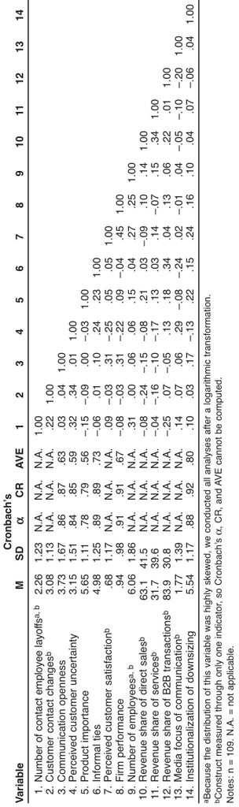

NOTE: complex table shown as an image of the PDF; the text below is a rough machine extraction and may be mis-aligned.

Page 8

**Customer Uncertainty Following Downsizing / 119**

Interaction effects may be methodological artifacts owing to true curvilinear effects of the variables (Ganzach 1997). To rule this out, we also analyzed models that included the square of open communication. The interaction terms still have a significant effect, whereas the squared term does not.

*Effects of customer uncertainty*. To test H4–H6, involving the effects of perceived customer uncertainty, we analyzed two additional regression models, summarized in Table 4. To test H4, which predicts a negative effect of customer uncertainty on customer satisfaction, we specified a model with perceived customer satisfaction as a dependent variable and perceived uncertainty plus control variables as independent variables. In support of H4, in this model, perceived uncertainty has a negative effect on perceived satisfaction (b = –.188, *p* < .01). To test H5, which predicts a negative effect of uncertainty on firm performance, we specified a similar model with firm performance as the

dependent variable. In support of H5, the regression coefficient of perceived uncertainty is negative and statistically significant (b = –.163, *p* < .01).

H6 predicts that customer uncertainty mediates the effect of the extent of downsizing on perceived customer satisfaction. Mediation is supported if a Sobel test indicates statistical significance and zero does not fall in a bootstrapped confidence interval around the indirect effect (Preacher and Hayes 2004). The Sobel test indicates that the indirect effects of the number of contact employee layoffs (bInd = –.069, SEInd = .034, *p* < .05) and of customer contact changes (bInd = –.053, SEInd = .030, *p* < .05) are statistically significant. Moreover, bootstrapped confidence intervals around the indirect effect of the number of layoffs (bLower-

### **Customer Study 1**

#### *Methodology*

*Objective, unit of analysis, and research design*. A limitation of our manager study is that managers assess customer uncertainty. Therefore, this study analyzes the effect of downsizing from the perspective of individual customers. We conduct an experimental study with the independent variables comprising the number of contact employee layoffs (small vs. large) and customer contact change (no change, contact employee stays but is out-

**TABLE 3 Results of the Manager Study: Antecedents of Customer Uncertainty**

[output not shown]

NOTE: table converted from PDF layout to HTML text; cell boundaries are reconstructed. See PDF if exact alignment matters.

**p* .05 (based on one–tailed tests). ***p* .01 (based on one–tailed tests). n.s.*p* > .05 (based on one–tailed tests). Notes: Unstandardized parameters are shown. Standard errors are in parentheses.

Page 9

sourced, layoff of contact employee with replacement, layoff of contact employee without replacement), resulting in a 2 4 between-subjects design. We test the communication hypotheses in a second customer study.

We used a scenario approach, which is ideal when studying negative experiences (Smith and Bolton 1998). We asked participants to imagine themselves as customers of a downsizing firm and to describe their reactions. Because the financial crisis has forced many banks to downsize, we chose a bank as context, giving our scenario extra external validity. In addition, banks are business-to-customer (B2C) firms, in which contact employees play a key role in service delivery (Dietz, Pugh, and Wiley 2004).

*Experimental procedure*. We contacted potential participants by e-mail using several databases available to us. Employing a snowball sampling approach, we asked our contacts to forward the e-mail to family and friends. The email directed participants to a website that contained the manipulations and a questionnaire.

The website was programmed in a way that participants were randomly assigned to experimental conditions. In this context, it should be noted that we added one level of the customer contact change factor (the outsourcing condition) to the experiment later at the suggestion of an anonymous

reviewer. Although we randomly assigned participants to the experimental groups for the initial experiment as well as to the two additional cells, we did this separately on two occasions. Thus, randomization may have been incomplete.

Participants were first asked to read a description of their relationship with an actual bank that had not engaged in downsizing at the time of the experiment (for confidentiality reasons, this is referred to here as Elite Bank). The description introduced a fictional person as the specific contact employee, followed by a fictional newspaper article stating the number of contact employee layoffs. Then, to manipulate customer contact change, participants learned the fate of their contact employee. Finally, they stated their uncertainty and responded to manipulation checks.

We pretested the experiment with 20 consumers differing in age and educational background. We screened their responses to the manipulation checks and then interviewed respondents who provided unexpected responses, after which we adjusted the wording of some of the manipulations. In addition, general feedback suggested that the interpretative leeway introduced by the fictional bank name used in the pretest induced uncertainty itself. Therefore, we decided to refer to a nonfictional bank. Appendix B reproduces the final manipulations.

**120 / Journal of Marketing, May 2012**

**FIGURE 2 Interaction Effects: Manager Study and Customer Study 2**

#### **A: Moderator: Product Importance**

#### **B: Moderator: Informal Ties**

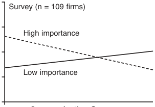

NOTE: figure/graphic rendered as an image from the PDF; its content is not machine-readable text. Caption (if any) follows as the next block.

**text found inside the figure**

High importance

Low importance

Survey (n = 109 firms)

Low Medium High

5.00

4.00

3.00

2.00

1.00 **Communication Openness**

#### **Perceived Customer**

#### **Uncertainty**

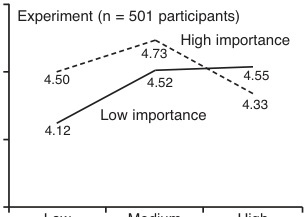

NOTE: figure/graphic rendered as an image from the PDF; its content is not machine-readable text. Caption (if any) follows as the next block.

**text found inside the figure**

High importance

Low importance

4.50

4.73

4.52 4.55

4.33

4.12

Experiment (n = 501 participants) 5.00

4.50

4.00

3.50

#### **Communication Openness**

#### **Customer Uncertainty**

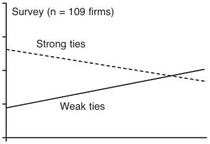

NOTE: figure/graphic rendered as an image from the PDF; its content is not machine-readable text. Caption (if any) follows as the next block.

**text found inside the figure**

Strong ties

Weak ties

Survey (n = 109 firms)

5.00

4.00

3.00

2.00

1.00 **Communication Openness**

#### **Perceived Customer**

#### **Uncertainty**

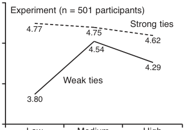

NOTE: figure/graphic rendered as an image from the PDF; its content is not machine-readable text. Caption (if any) follows as the next block.

**text found inside the figure**

Strong ties

Weak ties

4.77 4.75

4.54 4.62

4.29

3.80

Low Medium High

Experiment (n = 501 participants) 5.00

4.50

4.00

3.50

#### **Communication Openness**

#### **Customer Uncertainty**

Page 10

**Customer Uncertainty Following Downsizing / 121**

*Sampling*. To encourage participation, we offered participants an opportunity to enter a drawing in which they could win one of three coupons for a major online bookstore, worth $25 each. In response, 1209 people visited the website, and 39.7% of these visitors (480) began the experiment, leading to 405 completed questionnaires. Because the dropout rate of 15.6% is far lower than the 34% average dropout rate in online experiments (Musch and Reips 2000), we surmised that the incentive could have led participants to simply click through the experiment. Therefore, we dropped 90 participants (22.2%) who spent less than 30 seconds reading the scenario. We dropped another 41 participants (13%) because after the experiment they incorrectly stated the number of layoffs on a scale with four options. Our final sample size is 274 (with a mean cell size of 34.25). The average age of the participants was 31.0 years, and 52.9% of them were women. Moreover, 5.1% of the participants were actually customers of the nonfictional bank referred to in the scenario, which is remarkably close to the true 5% private client market share of the bank.

*Measures*. To measure customer uncertainty, we adapted the four items used in the manager study. Psychometric properties are good ( = .86, CR = .86, AVE = .60).

#### *Results*

*Manipulation and realism checks*. Manipulation checks revealed that our manipulations were successful. Appendix C provides details. We also performed a realism check using two items (Wagner, Hennig-Thurau, and Rudolph 2009): “I could imagine an actual bank doing the things

described in the situation earlier,” and “I believe that the described situation could happen in real life.” Psychometric properties are very good ( = .90, CR = .91, AVE = .84), and participants perceived the situation as highly realistic (MRealism = 6.09, SDRealism = 1.21).

*Hypothesis testing*. To assess our first two hypotheses, we first analyzed mean values in the different experimental cells. Figure 3 summarizes them graphically. As H1a predicts, for all conditions of customer contact change, customer uncertainty is higher for the large number of contact employee layoffs. In addition, as H1b predicts, customer uncertainty strongly depends on the extent of customer contact change.

*Robustness against performance problems explanation*. The financial information in the newspaper clipping provided to participants could also cause customer uncertainty. Therefore, along with collecting data for the main experiment (and using the same sampling approach), we collected data for two more experimental groups (2700 layoffs, no change of contact employee vs. permanent loss of contact employee), in which participants were told that the bank was in good financial shape and that it was conducting the downsizing proactively. Appendix B reports the manipulations. By applying the same criteria as in the main experiment, we arrived at a sample of 51 participants for the two new cells. We found no significant differences in customer uncertainty between the reactive and proactive downsizing conditions (F(1, 97) = .102, *p* = .75). Thus, the uncertainty results from downsizing and not from the financial situation of the firm.

### **Customer Study 2**

#### *Methodology*

*Objective, unit of analysis, and research design*. Customer Study 2 tests the two communication hypotheses (H2 and H3) from a customer perspective. Again, we conduct a scenario experiment in a banking context. We manipulated product importance (low vs. high), informal ties (weak vs. strong), and communication openness (low, medium, and high), resulting in a 2 2 3 design.

*Sampling design and experimental procedure*. We used the same sampling approach as in the first customer study. We randomly assigned participants to experimental conditions and then asked them to read a description of their relationship with the nonfictional bank we used before (still

**TABLE 4 Results of the Manager Study: Outcomes of**

#### **Customer Uncertainty**

|  | DependentVariable |  |
| --- | --- | --- |
|  | Perceived Customer Satisfaction | Market Performance |
| Perceivedcustomer | 188 (074)** –. . | 163 (064)** –. . |
| uncertainty |  |  |
| ControlVariables Institutionalizationof | 159 (092)* . . | .091 ( .079)n.s. |
| downsizing Revenueshareof | .003 ( .003)n.s. | 005 (003)* –. . |
| services Revenueshareof | –.005 ( .004)n.s. | .005 ( .003)n.s. |
| B2Btransactions Revenueshareof | 006 (003)* –. . | .002 ( .003)n.s. |
| directsales Firmsize | 178 (059)** . . | 146 (051)** . . |
| ModelCharacteristics R2 AdjustedR2 N | 204 . 154 . 109 | 178 . 126 . 109 |

NOTE: table converted from PDF layout to HTML text; cell boundaries are reconstructed. See PDF if exact alignment matters.

**p* .05 (based on one–tailed tests). ***p* .01 (based on one–tailed tests). n.s.*p* > .05 (based on one–tailed tests). Notes: Unstandardized parameters are shown. Standard errors are

in parentheses.

Page 11

called Elite Bank), while manipulating product importance and informal ties. In a second step, the customers learned that they had a new contact employee. Here, we manipulated communication openness by varying the amount of information provided and the way the customer was approached. Manipulations were pretested and are reported in Appendix D.

To encourage participation, we offered an opportunity to enter a drawing in which participants could win a popular tablet PC or one of five $25 coupons for an online bookstore. A total of 1379 people visited the website, and 52.7% of these visitors (727) began the experiment, leading to 652 completed questionnaires. As in the first customer study, we dropped 151 participants (23.2%) because they spent less than 30 seconds reading the scenario. The final sample contained 501 respondents and had an average cell size of 41.75. The average age of the participants in the final sample was 28.1 years, and 55.4% of them were women. The sample’s share of real customers of Elite Bank (9.7%) is slightly higher than its true market share (5%).

*Measures*. To measure customer uncertainty, we adapted the four items used in the first customer study. Psychometric properties are acceptable ( = .77, CR = .77, AVE = .46).

#### *Results*

*Manipulation and realism checks*. Manipulation checks revealed that our manipulations were successful. Appendix C provides details. Responses to the realism check ( = .91, CR = .91, AVE = .83) we also employed in the first customer study indicate that participants perceive the realism of the

described situation as high (MRealism = 5.67, SDRealism = 1.41).

*Hypothesis testing*. Figure 2 illustrates average customer uncertainty at the different factor levels. It also allows for a graphic comparison with the interaction plots from the manager study. As Figure 2 shows, the experimental results consistently reflect the general interaction pattern from the manager study. More specifically, at low levels of the moderators, customer uncertainty is greater in the high communication openness condition than in the low communication openness condition. Likewise, at high levels of the moderators, customer uncertainty is greater in the low than in the high communication openness condition.

This consistency extends to the hypothesis testing. The results from a full general linear model including customer affiliation with Elite Bank as a covariate support both H2 and H3. Interactions between product importance and open communication (F(2, 488) = 3.53, *p* < .05, <sup>2</sup> = .014) and between informal ties and open communication (F(2, 488) = 6.15, *p* < .01, <sup>2</sup> = .024) are statistically significant, whereas other interactions are not.

It is worth noting that Figure 2 suggests that the relationships may even be more complex in that a moderated curvilinear relationship could exist. To test this possibility, we estimated a moderated curvilinear regression model for each context factor while measuring the moderators through the respective manipulation check variables. In both models, the curvilinear interaction term has no statistically significant effect. Thus, overall the results from the experimental study are consistent with the results from the manager study.

**122 / Journal of Marketing, May 2012**

**FIGURE 3 Customer Uncertainty Under Different Conditions: Customer Study 1**

No Changes

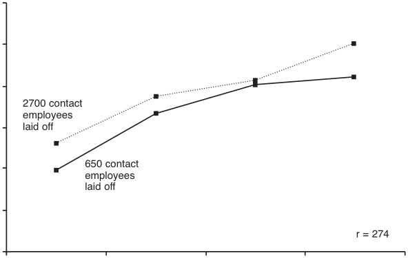

NOTE: figure/graphic rendered as an image from the PDF; its content is not machine-readable text. Caption (if any) follows as the next block.

**text found inside the figure**

2700 contact employees laid off

650 contact employees laid off

r = 274

Outsourcing Replacement Loss Without Replacement

7

6

5

4

3

2

1

#### **Extent of Personal Customer Contact Change**

#### **Customer Uncertainty**

Page 12

**Customer Uncertainty Following Downsizing / 123**

### **Discussion**

#### *Research Issues*

Downsizing is a highly relevant element of today’s business practice. However, despite its initial appeal, downsizing often does not deliver the expected results. When searching for reasons, researchers have mainly examined the workplace, paying little attention to customer reactions and how managers can influence them. The studies assembled here address these issues. Our findings advance academic knowledge in several ways.

First, consistently across studies and methods, our results clearly reveal that downsizing affects customer relationships. Thus, downsizing is an important problem for relationship marketing. In addition, this finding reinforces previous claims that marketing researchers should pay more attention to organizational restructurings (Homburg and Bucerius 2005). Second, we introduce the concept of customer uncertainty to the literature. Our manager study confirms that customer uncertainty plays a pivotal role in understanding outcomes of downsizing in that it completely mediates the effect of downsizing on customer satisfaction.

Third, across studies and methods, we consistently find that both facets of the extent of downsizing—that is, the number of contact employee layoffs and the extent of contact employee change—affect customer uncertainty. Notably, the number of contact employee layoffs also influences customer uncertainty if we control for the extent of customer contact changes. This finding implies that downsizing induces uncertainty in customers even if they face no personal consequences. Thus, it suggests that downsizing can also be a risk for firm–customer relationships when it does not involve employees in sales. Moreover, this finding provides evidence that customer uncertainty following downsizing reflects more than the customers’ simple preference for the status quo. This effect also becomes apparent in other results. For example, in our second experiment, the contact employee is replaced in all conditions, but in many conditions uncertainty still increases strongly if customers learn that this change is due to downsizing. Thus, customer uncertainty following downsizing cannot be reduced to being an instance of status quo bias. Downsizing may also act as a signal about the firm’s character, particularly its penchant for opportunistic behavior (Love and Kraatz 2009).

Fourth, the current investigation is one of the first empirical studies to address “what factors distinguish successful from unsuccessful downsizers” (Cascio, Young, and Morris 1997, p. 1188). In this regard, we focus on firm–customer communication, which is revealed to act in many ways like the proverbial double-edged sword. It is beneficial if customers consider a firm’s offerings to be of high importance and/ or if they have strong informal ties to the firm’s employees, but it may cause harm in other situations. Consistent with our theoretical reasoning, we are able to rule out that a true curvilinear effect of open communication or moderated curvilinear effects are the underlying reason behind these findings of moderated linear effects.

Notably, these results share a common theme with an otherwise fairly unrelated study by Berger, Sorensen, and

Rasmussen (2010), which finds that negative reviews of a book may increase or decrease sales, depending on whether the author was known before. This study and ours show that the very same message can have different effects depending on whether the target audience is highly involved with the subject.

This is an important implication for other research streams in marketing, such as research on dealing with a product-harm crisis (Dawar and Pillutla 2000). In research on crisis communication, a “the more the better” perspective seems to prevail. Our research suggests that it may be worthwhile to reconsider this perspective. As is the case for open downsizing communication, instead of helping, crisis communication may, under certain circumstances, also increase attention to an issue that may not have been perceived otherwise. According to our results, not communicating may be a strategy that sometimes works in an organizational crisis.

#### *Managerial Implications*

First, our results give additional emphasis to Cascio’s (2005, p. 45) advice to “think through the potential consequences of restructuring on customers.” Because internal turbulences that accompany downsizing often distract managers from considering its impact on customers, we believe that weighing the consequences is particularly important. Moreover, we advise managers to actively track the level of uncertainty among customers during the downsizing.

Moreover, our results clearly signal to managers the importance of influencing customer perceptions of the downsizing using an appropriate communication strategy. Here, managers have a difficult choice to make because according to our studies, two approaches (open vs. no communication) emerge as viable but under completely different circumstances. The decision flowchart in Figure 4 draws on our results to help managers in these situations.

First, managers need to consider the likelihood of visible media coverage of the downsizing, with visibility being defined in terms of customers’ typical media usage patterns. If customers will learn about the downsizing anyway, open communication (which includes a proactive component) is more likely to reduce uncertainty and increase long-term trust. Only if media coverage is unlikely should firms consider a no-communication strategy.

However, before implementing a no-communication strategy, a firm should carefully assess how much importance its customers place on its products and whether there are strong informal relationships between customers and contact employees. In particular, if perceptions of product importance rate 6 or more on a seven-point scale, no-communication strategies should be avoided. Similarly, according to our results, open communication is preferable if managerial perceptions of informal ties are higher than 5 on a sevenpoint scale. Managers can directly use our survey items to make this assessment themselves or adapt these items to a customer context.

In our analyses we assumed that a firm’s customer base is relatively homogenous with respect to these variables. If this is not the case, managers could consider engaging in

Page 13

open communication only with customers who perceive the firm’s products as important and/or who have strong informal ties with the employees. However, such a targeted communication strategy could have significant unintended ramifications and should be used with great caution. Most important, if there are strong ties between customers, it is likely that information will leak from informed to uninformed customers. This would probably lead to stronger negative reactions than when learning about the downsizing from the firm itself. Moreover, firms need to determine whether their legal and/or contractual obligations preclude the use of targeted communication.

#### *Limitations and Avenues for Further Research*

At least four limitations pertain to our study. First, the sample in the manager study reflects the difficulties of obtaining data on downsizing. The sample size of 109 firms is small and represents a specific mix of business types (average revenue share of the firms in the sample: 84% B2B vs. 16% B2C, 68% goods vs. 32% services, 63% direct sales vs. 37% indirect sales). Our results likely generalize only to firms with similar characteristics.

Second, most of our measures in the manager study were newly developed for this study (e.g., uncertainty, contact changes, communication). Researchers should be alert to the possibility that better measures exist. In addition, this study measures product importance and informal ties across all customers, ignoring possible heterogeneity, and we used key informants for all measures. A study matching key informant and customer data would be ideal.

Third, our scenario experiments address some of these issues, such as key informant measurement, individual differences in product importance, and/or informal ties. At the same time, the consumer samples employed in the experimental studies cover a sampling domain that has only a partial overlap with the sample of the manager study, limiting to some extent the informative value of the experiments with regard to the results of the manager study. Fourth, although we find statistically significant effects in support of most of our theoretical considerations, the effect sizes are often small, a result that should be taken into account when considering the practical implications of our findings.

Our study points to several avenues for further research: First, longitudinal designs would be ideal to more closely study the dynamics caused by open communication. More positive long-term effects could outweigh the negative short-term effects we find. Second, the role of the communication media deserves closer investigation. For example, our control variable measuring the focus on mass media communication positively affects uncertainty. Third, our argument behind H1 suggests that negative employee reactions to downsizing are transferred to customers, a phenomenon that deserves further analysis. Fourth, competitors could react to downsizing by intensifying efforts to attract customers from the downsizing firm. Therefore, the role of competitive actions as a driver of customer reactions to downsizing merits attention.

**124 / Journal of Marketing, May 2012**

**FIGURE 4 Downsizing Communication Decision Flowchart**

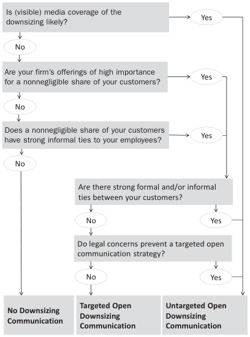

NOTE: figure/graphic rendered as an image from the PDF; its content is not machine-readable text. Caption (if any) follows as the next block.

**text found inside the figure**

Are your firm’s offerings of high importance for a nonnegligible share of your customers?

Does a nonnegligible share of your customers have strong informal ties to your employees?

Is (visible) media coverage of the downsizing likely?

#### **APPENDIX A Measures and Items: Manager Study**

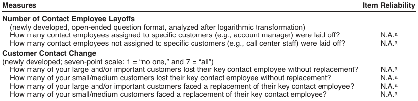

NOTE: complex table shown as an image of the PDF; the text below is a rough machine extraction and may be mis-aligned.

**extracted text (unreliable layout)**

Page 14

**Customer Uncertainty Following Downsizing / 125**

#### **APPENDIX A**

#### **Continued**

#### **Measures Item Reliability**

#### **Perceived Customer Uncertainty**

(based on Rafferty and Griffin 2006; seven-point scale: 1 = “strongly disagree,” and 7 = “strongly agree”) Many of our customers seemed uncertain about how to respond to the downsizing. .73 Many of our customers were unsure how severely the downsizing would affect them. .33 Many of our customers were worried that the downsizing would negatively affect their business relationship .82 with us. Many of our customers had doubts about the continuance of their business relationship with us. .51 **Communication Openness** (newly developed seven-point scale: 1 = “strongly disagree,” and 7 = “strongly agree”)

We openly informed our customers about the downsizing. .57 We informed our customers proactively about the downsizing. .79 We informed our customers about the downsizing in a timely manner. .77 Our customers received complete information about the downsizing. .39 **Informal Ties** (newly developed seven-point scale: 1 = “strongly disagree,” and 7 = “strongly agree”)

Typically, our customers and our customer-contact employees… … are often friends. .67 … have good and trusting personal relationships. .85 … have strong informal ties. .65 **Product Importance** (based on Moeller and Laaksonen 1986; seven-point scale: 1 = “strongly disagree,” and 7 = “strongly agree”)

Malfunctions of our products have serious consequences for our customers. .68 The buying decision in regard to our products is highly relevant for our customers. .42 Defects of our products lead to negative consequences for our customers. .56 **Perceived Customer Satisfaction** (based on Bowman and Narayandas 2004; seven-point scale: –3 = “clearly worse,” and +3 = “clearly better”)

After the downsizing, how has your business unit performed relative to your competitors regarding customer N.A.<sup>b</sup> satisfaction? **Firm Performance** (adapted from Narver and Slater 1990; seven-point scale: –3 = “clearly worse,” and +3 = “clearly better”)

After the downsizing, how has your business unit performed relative to your competitors with respect to… … achieving the desired revenue level? .69 … achieving the desired profit level? .42 … achieving/securing the desired market share? .77 … achieving/securing the desired market position? .67 … achieving the desired growth? .82 **Firm Size** (open-ended question format, analyzed after logarithmic transformation)

How many employees work in your business unit? N.A.<sup>b</sup>

**Media Focus of Communication** (newly developed seven-point scale: 1 = “strongly disagree,” and 7 = “strongly agree”)

To communicate to our customers about the downsizing, we mainly relied on mass media (traditional media N.A.<sup>b</sup> and Internet). **Institutionalization of Downsizing** (newly developed seven-point scale: 1 = “strongly disagree,” and 7 = “strongly agree”)

Our competitors also rely on downsizing to restructure their organizations. .87 Our competitors also use downsizing to increase their competitiveness. .84 Our downsizing project was no unique occurrence in our competitive environment. .69 **Revenue Share of Services** (newly developed, open-ended question format)

What percentage of the revenues of your business unit stem from selling services (versus manufactured N.A.<sup>b</sup> goods)? **Revenue Share of B2B Transactions**

What percentage of the revenues of your business unit stem from transactions with business customers N.A.<sup>b</sup> (vs. consumers)? **Revenue Share of Direct Sales** (newly developed, open-ended question format)

What percentage of the revenues of your business unit stem from direct sales (versus indirect sales, i.e., N.A.<sup>b</sup> retailing)?

aItems used to form index, the concept of item reliabilities cannot be applied here. bConstruct measured through single indicator, item reliabilities cannot be computed. Notes: N.A. = not applicable.

Page 15

### **Appendix B Background Information and Manipulations: Customer Study 1**

#### *Initial Background Information:*

You are a long-time customer at Elite Bank, where you hold a checking account and a money market account. In addition, you regularly use a credit card issued by this bank.

A few years ago, you decided to also set up a retirement account with this bank. You soon discovered that planning your retirement is a complicated matter, requiring you to evaluate different payment plans while considering consequences with regard to taxation. Additionally, you wanted to ensure the compatibility of your retirement plan with your plans to finance your own home in a few years. In this situation, you sought advice from Mr. Anderson, the customer contact employee at Elite Bank assigned to you. With his help, you were able to find a good solution for your needs.

This was not the first time Mr. Anderson had assisted you. For instance, you consulted him a few years ago, when you were looking for a possible investment for a small inheritance. Today, he knows your financial situation and your expectations quite well. He has proven to be a competent advisor. His recommendations have always turned out to be very valuable. You trust him and you are satisfied with his services.

#### *Manipulation of Number of Contact Employee Layoffs*

### Elite Bank cuts jobs in retail banking

650 [2700] employees will have to leave—Branch network to be tightened

Elite Bank said it plans to eliminate as many as [650/2700] jobs, or about [8%/33%] of its work force in the next year. The move was announced after the bank’s board meeting, yesterday. According to a bank’s representative, the lion’s share of layoffs will concern account managers in the retail banking department: “The cutbacks will be implemented as soon as possible to be really effective.” Additionally, it is planned to close a number of local branches (630 at the moment). In sum, these measures are rather [small/large], compared to the restructuring plans of other banks.

Analysts say that Elite Bank is in difficult circumstances and has been under considerable pressure in the past few years. The bank announced today that for last year it had a loss of 2.1 billion dollars. This loss substantially exceeded analysts’ expectations. A bank spokesperson said that owing to the unstable financial markets and the huge loss, an adjustment of the workforce was inevitable. The layoffs are part of a restructuring activity to overcome this heavy crisis.

#### *Manipulation of Customer Contact Change*

No consequences for the customer:

During your next visit in the bank, you find out that the downsizing does not have any consequences for you, personally. Mr. Anderson continues to be your customer contact employee.

Outsourcing of contact employee:

During your next visit in the bank, you find out that Mr. Anderson will continue to be your customer contact employee, but that he no longer works for Elite Bank. Consulting for private clients is now provided by a third firm that has reached a cooperation agreement with the bank. Mr. Anderson is now an employee of this external service provider, but he will keep his office in your branch of the bank.

Replacement of contact employee:

During your next visit in the bank, you find out that the downsizing has consequences for you, personally. Mr. Anderson has been laid off in the course of the downsizing. In the future, a different customer contact employee will be responsible for you.

Permanent loss of contact employee:

During your next visit in the bank, you find out that the downsizing has consequences for you, personally. Mr. Anderson has been laid off in the course of the downsizing. You are directed to an online portal, which will replace your personal contact employee.

#### *Manipulation of Reason for Downsizing (Used in Stability Test)*

### Elite Bank cuts jobs in retail banking

2700 employees will have to leave—Branch network to be tightened

Elite Bank said it plans to eliminate as many as 2700 jobs, or about 33% of its work force in the next year. The move was announced after the bank’s board meeting, yesterday. According to a bank’s representative, the lion’s share of layoffs will concern account managers in the retail banking department: “The cutbacks will be implemented as soon as possible to be really effective.” Additionally, it is planned to close a number of local branches (630 at the moment). In sum, these measures are rather large, compared to the restructuring plans of other banks.

Analysts say that Elite Bank is in a comfortable position and never had to face as much pressure as most competitors in the past years. The bank announced today that in the past year it made a profit of 2.1 billion dollars. This profit substantially exceeded analysts’ expectations. A bank spokesperson stated the bank intended to seize this opportunity to secure the strong market position of the bank over the long term. The layoffs are part of a restructuring activity to align the company toward this goal.

**126 / Journal of Marketing, May 2012**

[output not shown]

NOTE: table converted from PDF layout to HTML text; cell boundaries are reconstructed. See PDF if exact alignment matters.

#### **APPENDIX C Manipulation Checks for Customer Studies 1 and 2**

Page 16

**Customer Uncertainty Following Downsizing / 127**

### **Appendix D Background Information and Manipulations: Customer Study 2**

#### *Background Information and Manipulation of Product Importance and Informal Ties*

You are a long-time customer at Elite Bank, where you hold a checking account. Every month your salary is transferred electronically to this account. You use the money from this account for everyday transactions and to pay some recurring bills. Typically, at the end of the month, there is little money left in this account.

*Low importance*. For larger transactions you use a different checking account that you hold at another bank. Your credit card is also issued by this other bank. Additionally, at the other bank you hold a money market account. They also manage a small stock portfolio of yours.

*High importance*. Your credit card is also issued by Elite Bank. Additionally, you hold a money market account with them and they manage a small stock portfolio of yours. A few years ago, you also set up a retirement account with this bank. You soon discovered that planning your retirement is a complicated matter. Together with the bank you were able to find a good solution for your needs that is also compatible with your plans to finance your own home in a few years.

Elite Bank has assigned a customer contact employee to you: Mr. Anderson. He has proven to be a competent and reliable advisor.

*Weak ties*. During the years, your relationship with Mr. Anderson has remained purely professional. You don’t have a personal relationship outside the bank and your conversations focus almost exclusively on banking.

*Strong ties*. During the years, between you and Mr. Anderson a strong personal relationship has developed. You would describe it as amicable and trusting. In your conversations you talk freely and informally about private and professional issues. For instance, you have learnt that Mr. Anderson likes to spend as much of his spare time as possible with his children Marc and Anne. Moreover, he is a passionate sports fan who sometimes even travels to attend away games of his teams.

#### *Manipulation of Communication Openness*

*Low openness*. The next time you call Elite Bank, a Mr. Brown answers the phone. Among other things, he tells you the following: “There has been an important change for you. In the future, instead of Mr. Anderson, I will be your contact employee. I would love to meet you in person as soon as possible. At this opportunity, I would also like to present you some new insurance products that could be very interesting for you.”

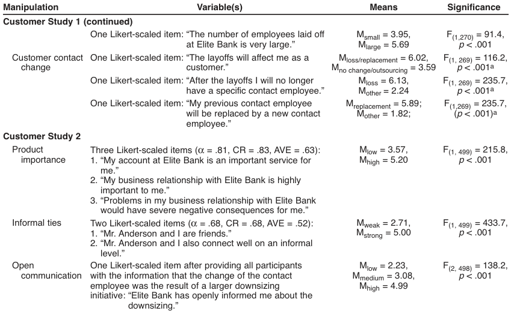

NOTE: complex table shown as an image of the PDF; the text below is a rough machine extraction and may be mis-aligned.

**extracted text (unreliable layout)**

#### **APPENDIX C**

#### **Continued**

aWe also included the overall number of layoffs factor in the model. Neither its main effects nor possible interactions are significant. Thus, the

two manipulations are independent from each other.

Page 17

*Medium openness*. The next time you call Elite Bank, a Mr. Brown answers the phone. Among other things, he tells you the following: “There has been an important change for you. In the future, instead of Mr. Anderson, I will be your contact employee. I would love to meet you in person as soon as possible. At this opportunity, I would also like to present you some new insurance products that could be very interesting for you.” Upon your inquiries, he explains that this change is the result of a firm-wide restructuring project accompanied by large scale employee downsizing.

*High openness*. You get a call from a Mr. Brown from Elite Bank. Among other things, he tells you the following: “I am calling you to inform you before the press conference tomorrow about a firm-wide restructuring. We would like to explain to you, why the restructuring has become necessary

and what it means for you, as a customer…. In today’s tough competitive environment—something we notice daily in our local branch as well—restructuring could no longer be postponed. Unfortunately, the restructuring will be accompanied by large-scale employee downsizing. As a result, something important has changed for you as well. Instead of Mr. Anderson, I will be you contact employee…. We know that a restructuring like this raises a lot of questions for you. For answers, you can call me anytime. Additionally, there will be a special telephone hotline available to you that you can reach daily under 555-871004 between 8 A.M. and 10 P.M. …. I would love to meet you in person as soon as possible. At this opportunity, I would also like to present you some new insurance products that could be very interesting for you.”

**128 / Journal of Marketing, May 2012**

ing,” *Academy of Management Executive*, 19 (4), 39–50. ———, Clifford E. Young, and James R. Morris (1997), “Financial

Consequences of Employment-Change Decisions in Major U.S. Corporations,” *Academy of Management Journal*, 40 (5), 1175–89. Chadwick, Clint, Larry W. Hunter, and Stephen L. Walston (2004),

“Effects of Downsizing Practices on the Performance of Hospitals,” *Strategic Management Journal*, 25 (5), 405–427. Cohen, Jacob, Patricia Cohen, Stephen G. West, and Leona S.

Aiken (2003), *Applied Multiple Regression/Correlation Analysis for the Behavioral Sciences*, 3d ed. Mahwah, NJ: Lawrence Erlbaum Associates. Coombs, W. Timothy (1999), *Ongoing Crisis Communication*.

Thousand Oaks, CA: Sage Publications. Datta, Deepak K., James P. Guthrie, Dynah Basuil, and Alankrita

Pandey (2010), “Causes and Effects of Employee Downsizing: A Review and Synthesis,” *Journal of Management*, 36 (1), 281–348. Dawar, Niraj and Madan M. Pillutla (2000), “Impact of Product-

Harm Crises on Brand Equity: The Moderating Role of Consumer Expectations,” *Journal of Marketing Research*, 37 (May), 215–26. Dietz, Joerg, S. Douglas Pugh, and Jack W. Wiley (2004), “Ser-

vice Climate Effects on Customer Attitudes: An Examination of Boundary Conditions,” *The Academy of Management Journal*, 47 (1), 81–92. DiFonzo, Nicholas and Prashant Bordia (1998), “A Tale of Two

Corporations: Managing Uncertainty During Organizational Change,” *Human Resource Management*, 37 (3/4), 295–303. ———, ———, and Ralph, L. Rosnow (1994), “Reining in

Rumors,” *Organizational Dynamics*, 23 (1), 47–62. Fornell, Claes and David Larcker (1981), “Evaluating Structural

Equation Models with Unobservable Variables and Measurement Error,” *Journal of Marketing Research*, 18 (February), 39–50. Freeman, Sarah J. and Kim S. Cameron (1993), “Organizational

Downsizing: A Convergence and Reorientation Framework,” *Organization Science*, 4 (1), 10–29.

#### **REFERENCES** Anderson, Eugene W., Claes Fornell, and Roland T. Rust (1997),

“Customer Satisfaction, Productivity, and Profitability: Differences Between Goods and Services,” *Marketing Science*, 16 (2), 129–45. Arpan, Laura M. and Donnalyn Pompper (2003), “Stormy

Weather: Testing ‘Stealing Thunder’ as a Crisis Communication Strategy to Improve Communication Flow Between Organizations and Journalists,” *Public Relations Review*, 29 (3), 291–308. Bastien, David T. and Todd J. Hostager (2003), “Resizing and the

Marketplace: The Response of Customers and Competitors to Reorganization,” in *Resizing the Organization: Managing Layoff, Divestitures, and Closings*, Kenneth P. de Meuse and Mitchell L. Marks, eds. San Francisco: Jossey-Bass, 157–87. Baumol, William J., Alan S. Blinder, and Edward N. Wolff (2003),

*Downsizing in America: Reality, Causes, and Consequences*. New York: Russell Sage Foundation. Bendapudi, Neeli and Robert P. Leone (2001), “How to Lose Your

Star Performer Without Losing Customers, Too,” *Harvard Business Review*, 79 (10), 104–112. ——— and ——— (2002), “Managing Business-to-Business Cus-

tomer Relationships Following Key Contact Employee Turnover in a Vendor Firm,” *Journal of Marketing*, 66 (April), 83–101. Bennett, Nathan, Christopher L. Martin, Robert J. Bies, and Joel

Brockner (1995), “Coping with a Layoff: A Longitudinal Study of Victims,” *Journal of Management*, 21 (6), 1025–40. Berger, Charles R. and Richard J. Calabrese (1975), “Some Explo-

rations in Initial Interaction and Beyond: Toward a Development Theory of Interpersonal Communication,” *Human Communication Research*, 1 (2), 99–112. Berger, Jonah, Alan T. Sorensen, and Scott J. Rasmussen (2010),

“Positive Effects of Negative Publicity: When Negative Reviews Increase Sales,” *Marketing Science*, 29 (1), 815–27. Boulding, William, Ajay Kalra, Richard Staelin, and Valerie A.

Zeithaml (1993), “A Dynamic Process Model of Service Quality: From Expectations to Behavioral Intentions,” *Journal of Marketing Research*, 30 (February), 7–27. Bowman, Douglas and Das Narayandas (2004), “Linking Cus-

tomer Management Effort to Customer Profitability in Business Markets,” *Journal of Marketing Research*, 41 (November), 433–47. Brockner, Joel, Steven L. Grover, Thomas F. Reed, and Rocki

DeWitt (1992), “Layoffs, Job Insecurity, and Survivor’s Work Effort: Evidence of an Inverted-U Relationship,” *Academy of Management Journal*, 35 (2), 413–25. ———, Gretchen Spreitzer, Aneil Mishra, Wayne Hochwarter,

Page 18

**Customer Uncertainty Following Downsizing / 129**

Ganesan, Shankar (1994), “Determinants of Long-Term Orienta-

tion in Buyer–Seller Relationships,” *Journal of Marketing*, 58 (April), 1–19. Ganzach, Yoav (1997), “Misleading Interaction and Curvilinear

Terms,” *Psychological Methods*, 2 (2), 235–47. Grice, Paul (1989), *Studies in the Way of Words*. Cambridge, MA:

Harvard University Press. Guthrie, J.P. and D.K. Datta (2008), “Dumb and Dumber: The

Impact of Downsizing on Firm Performance as Moderated by Industry Conditions,” *Organization Science*, 19 (1), 108–123. Hirshleifer, Jack and John G. Riley (2002), *The Analytics of*

*Uncertainty and Information*. Cambridge, UK: Cambridge University Press. Homburg, Christian and Matthias Bucerius (2005), “A Marketing

Perspective on Mergers and Acquisitions: How Marketing Integration Affects Postmerger Performance,” *Journal of Marketing*, 69 (January), 95–113. Irwin, Julie R. and Gary H. McClelland (2001), “Misleading

Heuristics and Moderated Multiple Regression Models,” *Journal of Marketing Research*, 38 (February), 100–109. Kaufmann, Jeffrey B., Idalene F. Kesner, and Thomas Lee Hazen

(1994), “The Myth of Full Disclosure: A Look at Organizational Communications During a Crisis,” *Business Horizons*, 37 (4), 29–39. Levinson, Stephen C. (1983), *Pragmatics*. Cambridge, UK: Cam-

bridge University Press. Lewin, Jeffrey E. (2001), “The Effects of Downsizing on Organi-

zational Buying Behavior: An Empirical Investigation,” *Journal of the Academy of Marketing Science*, 29 (2), 151–64. ——— (2003), “An Empirical Investigation of the Effects of

Downsizing on Buyer–Seller Relationships,” *Journal of Business Research*, 56 (4), 283–93. ——— (2009), “Business Customers’ Satisfaction: What Happens

When Suppliers Downsize?” *Industrial Marketing Management*, 38 (3), 283–99. ——— and Wesley J. Johnston (2008), “The Impact of Supplier

Downsizing on Performance, Satisfaction over Time, and Repurchase Intentions,” *Journal of Business & Industrial Marketing*, 23 (4), 249–55. ———, Wim Biemans, and Wolfgang Ulaga (2010), “Firm Down-

sizing and Satisfaction Among United States and European Customers,” *Journal of Business Research*, 63 (7), 697–706. Love, Geoffey E. and Matthew Kraatz (2009), “Character, Confor-

mity, or the Bottom Line? How and Why Downsizing Affected Corporate Reputation,” *Academy of Management Journal*, 52 (2), 314–35. ——— and Nitin Nohria (2005), “Reducing Slack: The Perfor-

mance Consequences of Downsizing by Large Industrial Firms,” *Strategic Management Journal*, 26 (12), 1977–93. McElroy, James C., Paula C. Morrow, and Scott N. Rude (2001),

“Turnover and Organizational Performance: A Comparative Analysis of the Effects of Voluntary, Involuntary, and Reduction-in-Force Turnover,” *Journal of Applied Psychology*, 86 (6), 1294–99. Moeller, Kristian K.E. and Martti Laaksonen (1986), “Situational

Dimensions and Decision Criteria in Industrial Buying: Theoretical and Empirical Analysis,” in *Advances in Business Marketing*, Vol. 1, A. Woodside, ed. Amsterdam: Elsevier, 163–207. Musch, Jochen and Ulf-Dietrich Reips (2000), “A Brief History of

Web Experimenting,” in *Psychological Experiments on the Internet*, Michael H. Birnbaum, ed. San Diego: Academic Press, 61–88.

Narver, John C. and Stanley F. Slater (1990), “The Effect of a

Market Orientation on Business Profitability,” *Journal of Marketing*, 54 (October), 20–35. Oliver, R.L. (1997), *Satisfaction: A Behavioral Perspective on the*

*Consumer*. New York: McGraw-Hill. Palmatier, Robert W., Rajiv P. Dant, Dhruv Grewal, and Kenneth

R. Evans (2006), “Factors Influencing the Effectiveness of Relationship Marketing: A Meta-Analysis,” *Journal of Marketing*, 70 (October), 136–53. ———, Lisa K. Scheer, and Jan-Benedict E.M. Steenkamp (2007),

“Customer Loyalty to Whom? Managing the Benefits and Risks of Salesperson-Owned Loyalty,” *Journal of Marketing Research*, 44 (May), 185–99. Pines, Wayne L. (1985), “How to Handle a PR Crisis: Five Dos

and Five Don’ts,” *Public Relations Quarterly*, 30 (2), 16–19. Podsakoff, Philip M., Scott B. MacKenzie, Jeong-Yeon Lee, and

Nathan P. Podsakoff (2003), “Common Method Biases in Behavioral Research: A Critical Review of the Literature and Recommended Remedies,” *Journal of Applied Psychology*, 88 (5), 879–903. Preacher, Kristopher J. and Andrew F. Hayes (2004), “SPSS and

SAS Procedures for Estimating Indirect Effects in Simple Mediation Models,” *Behavior Research Methods, Instruments, & Computers*, 36 (4), 717–31. Rafferty, Alannah E. and Mark A. Griffin (2006), “Perceptions of

Organizational Change: A Stress and Coping Perspective,” *Journal of Applied Psychology*, 91 (5), 1154–62. Reimann, Martin, Ulrich F. Lünemann, and Richard B. Chase

(2008), “Uncertainty Avoidance as a Moderator of the Relationship Between Perceived Service Quality and Customer Satisfaction,” *Journal of Service Research*, 11 (1), 63–73. Rindfleisch, Aric and Jan B. Heide (1997), “Transaction Cost

Analysis: Past, Present, and Future Applications,” *Journal of Marketing*, 61 (October), 30–54. Samuelson, William and Richard Zeckhauser (1988), “Status Quo

Bias in Decision Making,” *Journal of Risk and Uncertainty*, 1 (1), 7–59. Schweiger, David M. and Angelo S. Denisi (1991), “Communica-

tion with Employees Following a Merger: A Longitudinal Field Experiment,” *Academy of Management Journal*, 34 (1), 110–35. Smith, Amy K. and Ruth N. Bolton (1998), “An Experimental

Investigation of Customer Reactions to Service Failure and Recovery Encounter—Paradox or Peril?” *Journal of Service Research*, 1 (1), 65–81. Trevor, Charlie O. and Anthony J. Nyberg (2008), “Keeping Your

Headcount When All About You Are Losing Theirs: Downsizing, Voluntary Turnover Rates, and the Moderating Role of HR Practices,” *Academy of Management Journal*, 52 (1), 259–76. Wagner, Tillmann, Thorsten Hennig-Thurau, and Thomas Rudolph

(2009), “Does Customer Demotion Jeopardize Loyalty?” *Journal of Marketing*, 73 (May), 69–85. Woodruff, Robert B., Ernest R. Cadotte, and Roger L. Jenkins

(1983), “Modeling Customer Satisfaction Processes Using Experience-Based Norms,” *Journal of Marketing Research*, 20 (August), 296–304. Zeithaml, Valerie A., Leonard L. Berry, and A. Parasuraman

(1993), “The Nature of Determinants of Customer Expectations of Service,” *Journal of the Academy of Marketing Science*, 21 (1), 1–12.

Page 19